# Final model

Etibar Aliyev

4/24/2020

**Packages**

```r
library("dplyr")
library("naniar")
library(magrittr)
library("car")
library("caret")
library("tidyverse")
library(broom)
theme_set(theme_classic())
library(pROC)
library("ROCR")
```

**Read data**

```r
diabetic <- read.csv(file="diabetic.csv", header=T, na.strings = "?")
diabetic2 <- subset(diabetic, select=-c(weight,payer_code))
```

#Recoding #Early readmission variable

```r
diabetic2 %<>%
mutate(early.readmit=case_when(
 readmitted  %in% "<30" ~ 1,
 readmitted %in% c(">30","NO") ~ 0 ))
```

#Create new HbA1c variable

```r
diabetic2$HbA1c <- ifelse(diabetic$A1Cresult == "None","None",
ifelse(diabetic$A1Cresult == '>8' & diabetic2$change == 'Ch','High-change',      ifelse(diabetic$A1Cresult == '>8' & diabetic2$change == 'No','High-no change',   ifelse(diabetic$A1Cresult == '>7' | diabetic2$A1Cresult == 'Norm','Normal',0))))
```

#Gender

```r
diabetic2 %<>% replace_with_na(replace = list(gender = "Unknown/Invalid"))
```

#Discharge disposition

```r
diabetic2 %<>%
mutate(discharge_disposition=case_when(
 discharge_disposition_id %in% 1 ~ "Discharged to home",
 discharge_disposition_id %in% 2:29 ~ "Otherwise" ))
```

#Admission source

```r
diabetic2 %<>%
mutate(admission.source=case_when(
 admission_source_id %in% c(7) ~ "Emergency",
 admission_source_id %in% c(1,2) ~ "Physician/Clinic",
 admission_source_id %in% c(3:6,8:26) ~ "Otherwise"
))
```

#Admitting physician specialty

```r
diabetic2$admit.spec <-
ifelse(is.na(diabetic2$medical_specialty), "Unknown",
ifelse(diabetic2$medical_specialty == "InternalMedicine","IntMed",
ifelse(diabetic$medical_specialty == 'Cardiology','Card',      ifelse(startsWith(as.character(diabetic2$medical_specialty), "Surg"),'Surg',   ifelse(diabetic2$medical_specialty == 'Family/GeneralPractice','F-GP', 'Other')))))
```

#Primary diagnosis

```r
diabetic2$prim.diag <- ifelse(diabetic2$diag_1>=390 &                                                             diabetic2$diag_1<=459 |
                              diabetic2$diag_1==785,
                              "Circulatory",
                       ifelse(diabetic2$diag_1>=460 &
                              diabetic2$diag_1<=519 |
                              diabetic2$diag_1==786,
                              "Respiratory",
                       ifelse(diabetic2$diag_1>=520 &
                              diabetic2$diag_1<=579 |
                              diabetic2$diag_1==787,
                              "Digestive",
                       ifelse(diabetic2$diag_1>=250.0 &
                              diabetic2$diag_1<251.0,
                              "Diabetes",
                       ifelse(diabetic2$diag_1>=800 &
                              diabetic2$diag_1<=999,
                              "Injury",
                       ifelse(diabetic2$diag_1>=710 &
                              diabetic2$diag_1<=739,
                              "Musculoskeletal",
                       ifelse(diabetic2$diag_1>=580 &
                              diabetic2$diag_1<=629 |
                              diabetic2$diag_1==788,
                              "Genitourinary",
                       ifelse(diabetic2$diag_1>=140 &
                              diabetic2$diag_1<=239,
                              "Neoplasms", "Other"))))))))
View(diabetic2$prim.diag)
```

#Race

```r
diabetic2 %<>%
mutate(race2=case_when(
 race %in% c("AfricanAmerican")~"AfricanAmerican" ,
 race %in% c("Caucasian")~"Caucasian" ,
 race %in% c("Asian","Hispanic","Other")~"Other" ,
 is.na(race)~"Missing"
))
```

#Age

```r
diabetic2 %<>%
mutate(age3=case_when(
 age %in% c("[0-10)","[10-20)","[20-30)")~"30 years old or younger" ,
 age %in% c("[30-40)","[40-50)","[50-60)")~"30 years old to 60 years old" ,
 age %in% c("[60-70)","[70-80)","[80-90)","[90-100)")~"60 years old or older"
))
```

#Create numeric Age variable

```r
diabetic2 %<>%
mutate(age.num=case_when(
 age %in% c("[0-10)")~5 ,
 age %in% c("[10-20)")~15 ,
 age %in% c("[20-30)")~25 ,
 age %in% c("[30-40)")~35 ,
 age %in% c("[40-50)")~45 ,
 age %in% c("[50-60)")~55 ,
 age %in% c("[60-70)")~65 ,
 age %in% c("[70-80)")~75 ,
 age %in% c("[80-90)")~85 ,
 age %in% c("[90-100)")~95
))
```

#Drop observations Select first patient visit if multiple visits: Results in 71518 observations.

```r
diabetic.unique <- distinct(diabetic2, patient_nbr, .keep_all= TRUE)
```

#Remove patients discharged to hospice: Results in 70198 observations

```r
diabetic.unique2 <- subset(diabetic.unique, discharge_disposition_id != 13)
diabetic.unique3 <- subset(diabetic.unique2, discharge_disposition_id!=14)
```

#Remove patients who died: Results in 69973 observations.

```r
diabetic.unique4 <- subset(diabetic.unique3, discharge_disposition_id!=11)

diabetic.unique5 <- subset(diabetic.unique4, discharge_disposition_id!=19)

diabetic.unique6 <- subset(diabetic.unique5, discharge_disposition_id!=20)

diabetic.unique7 <- subset(diabetic.unique6, discharge_disposition_id!=21)
```

**Logistic regression diagnostics**

#Descriptives: Table: Checking class bias

```r
table(diabetic.unique7$early.readmit)
```

```
##
##     0     1
## 63696  6277
```

#Clearly there is a class bias

#glm w/o training, testing split

```r
diabetic.unique7$prim.diag <- relevel(factor(diabetic.unique7$prim.diag), ref='Diabetes')

glm1 <- glm(early.readmit~discharge_disposition_id+admission_source_id+
                              admit.spec+prim.diag+race2+age3+time_in_hospital+HbA1c+
                              discharge_disposition:admit.spec+
                              discharge_disposition:prim.diag+
                              discharge_disposition:race2+
                              discharge_disposition:time_in_hospital+
                              admission.source:age3+
                              admit.spec:age3+
                              admit.spec:prim.diag+
                              admit.spec:time_in_hospital+
                              prim.diag:time_in_hospital+
                              HbA1c:prim.diag,
                     diabetic.unique7, family = binomial, na.action= na.exclude)
summary(glm1)
```

```
##
## Call:
## glm(formula = early.readmit ~ discharge_disposition_id + admission_source_id +
##     admit.spec + prim.diag + race2 + age3 + time_in_hospital +
##     HbA1c + discharge_disposition:admit.spec + discharge_disposition:prim.diag +
##     discharge_disposition:race2 + discharge_disposition:time_in_hospital +
##     admission.source:age3 + admit.spec:age3 + admit.spec:prim.diag +
##     admit.spec:time_in_hospital + prim.diag:time_in_hospital +
##     HbA1c:prim.diag, family = binomial, data = diabetic.unique7,
##     na.action = na.exclude)
##
## Deviance Residuals:
##     Min       1Q   Median       3Q      Max
## -0.8892  -0.4810  -0.3973  -0.3418   2.9927
##
## Coefficients:
##                                                                     Estimate
## (Intercept)                                                        -1.304496
## discharge_disposition_id                                            0.012131
## admission_source_id                                                 0.007935
## admit.specF-GP                                                     -2.604078
## admit.specIntMed                                                   -2.136919
## admit.specOther                                                    -2.816924
## admit.specSurg                                                     -3.058899
## admit.specUnknown                                                  -1.490678
## prim.diagCirculatory                                               -0.019754
## prim.diagDigestive                                                 -0.407749
## prim.diagGenitourinary                                             -0.504456
## prim.diagInjury                                                    -0.020562
## prim.diagMusculoskeletal                                          -11.332235
## prim.diagNeoplasms                                                -11.866896
## prim.diagOther                                                      0.007565
## prim.diagRespiratory                                               -0.628832
## race2Caucasian                                                      0.006899
## race2Missing                                                       -0.321989
## race2Other                                                         -0.307025
## age330 years old to 60 years old                                   -1.788289
## age360 years old or older                                          -1.404278
## time_in_hospital                                                    0.129502
## HbA1cHigh-no change                                                -0.132734
```

[output cut: 520 more lines]

```
## prim.diagMusculoskeletal:HbA1cNormal                              0.048230 *
## prim.diagNeoplasms:HbA1cNormal                                    0.536761
## prim.diagOther:HbA1cNormal                                        0.178519
## prim.diagRespiratory:HbA1cNormal                                  0.005103 **
## ---
## Signif. codes:  0 '***' 0.001 '**' 0.01 '*' 0.05 '.' 0.1 ' ' 1
##
## (Dispersion parameter for binomial family taken to be 1)
##
##     Null deviance: 42233  on 69962  degrees of freedom
## Residual deviance: 41122  on 69827  degrees of freedom
##   (10 observations deleted due to missingness)
## AIC: 41394
##
## Number of Fisher Scoring iterations: 12
```

#Brief interpretation of variables: #One unit change in positive estimates will result in increase of log odds of early readmit given that p-values are statistically significant. Conversely negative estimates will decrease the log odds of early readmit provided that p-values are within significance level.

#The difference between Null and residual deviance clearly proves that the model is good fit. Greater the difference the better model we have as null model takes only early.readmit against null value, residual one takes early readmit against all variables.

#It is important to mention that not all outliers are influential observations. The standardized residual error might be useful to detect whether the data contains potential influential observations. Data points with an absolute standardized residuals above 3 represent possible outliers and may deserve closer attention.

**Outlier detection**

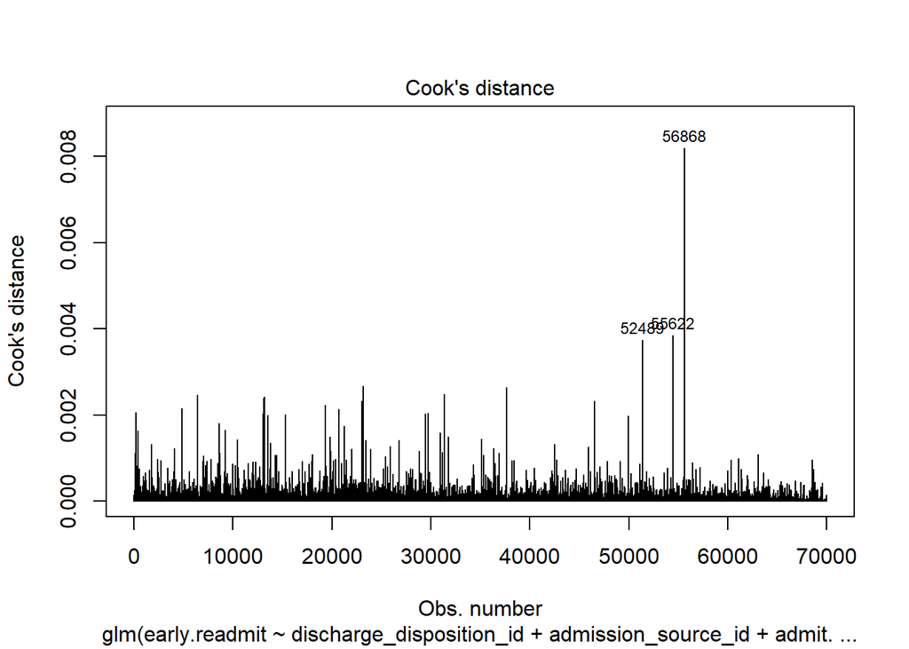

```r
plot(glm1, which = 4, id.n = 3)
```

```r
# Extract model results
model.data <- augment(glm1, na.action=na.exclude) %>%
  mutate(index = 1:n())
```

#The data for the top 3 largest values, according to the Cook’s distance, can be displayed as follow

```r
model.data %>% top_n(3, .cooksd)
```

```
## # A tibble: 3 x 20
##   .rownames early.readmit discharge_dispo~ admission_sourc~ admit.spec prim.diag
##   <chr>             <dbl>            <int>            <int> <chr>      <fct>
## 1 52489                 1                1                1 Card       Circulat~
## 2 55622                 1                1                1 Card       Other
## 3 56868                 1                1                1 Surg       Neoplasms
## # ... with 14 more variables: race2 <chr>, age3 <chr>, time_in_hospital <int>,
## #   HbA1c <chr>, discharge_disposition <chr>, admission.source <chr>,
## #   .fitted <dbl>, .se.fit <dbl>, .resid <dbl>, .hat <dbl>, .sigma <dbl>,
## #   .cooksd <dbl>, .std.resid <dbl>, index <int>
```

#Plotting the standardized residuals.

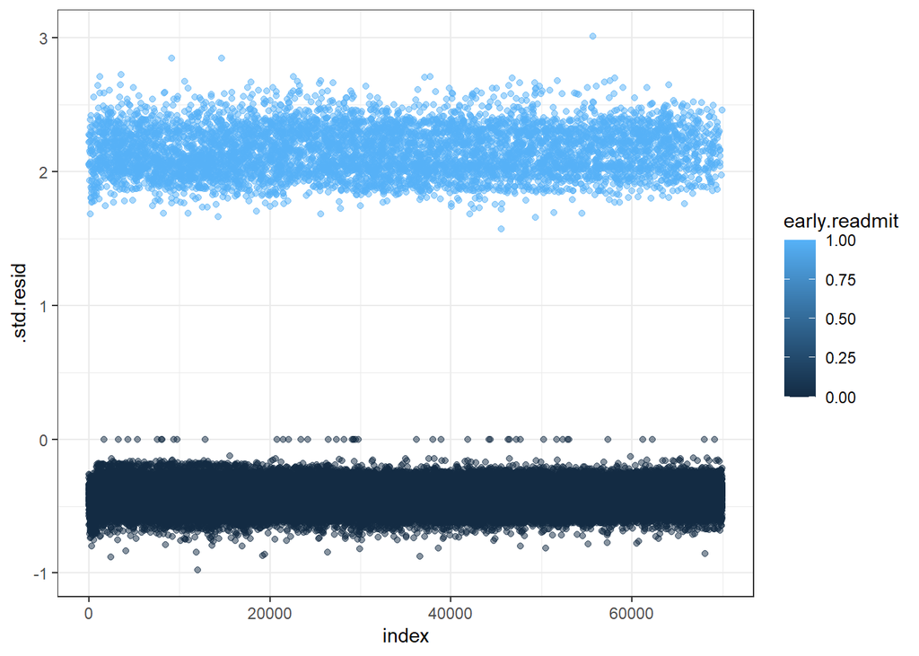

```r
ggplot(model.data, aes(index, .std.resid)) +
  geom_point(aes(color = early.readmit), alpha = .5) +
  theme_bw()
```

```r
model.data %>%
  filter(abs(.std.resid) > 3)
```

```
## # A tibble: 1 x 20
##   .rownames early.readmit discharge_dispo~ admission_sourc~ admit.spec prim.diag
##   <chr>             <dbl>            <int>            <int> <chr>      <fct>
## 1 56868                 1                1                1 Surg       Neoplasms
## # ... with 14 more variables: race2 <chr>, age3 <chr>, time_in_hospital <int>,
## #   HbA1c <chr>, discharge_disposition <chr>, admission.source <chr>,
## #   .fitted <dbl>, .se.fit <dbl>, .resid <dbl>, .hat <dbl>, .sigma <dbl>,
## #   .cooksd <dbl>, .std.resid <dbl>, index <int>
```

#If we consider standardized residuals in range (-3, 3) we will find out that according to the plot and the filter only one point is above 3. Previously given cook’s distance was visually showing only 1 point as well. Additionally, the scale of this 1 point is around 0.008 which is quite lower. Therefore, based on argumentation one can claim that given point is not influential.

**Multicollinearity**

```r
car::vif(glm1)
```

```
##                                                GVIF Df GVIF^(1/(2*Df))
## discharge_disposition_id               1.550143e+00  1        1.245047
## admission_source_id                    3.304497e+00  1        1.817828
## admit.spec                             3.171198e+10  5       11.223346
## prim.diag                              3.241515e+24  8       34.034687
## race2                                  7.715527e+00  3        1.405705
## age3                                   1.731148e+03  2        6.450354
## time_in_hospital                       3.665503e+01  1        6.054340
## HbA1c                                  3.936597e+02  3        2.707199
## admit.spec:discharge_disposition       1.269300e+03  6        1.813971
## prim.diag:discharge_disposition        8.410742e+03  8        1.759147
## race2:discharge_disposition            2.870436e+01  3        1.749812
## time_in_hospital:discharge_disposition 6.229304e+00  1        2.495857
## age3:admission.source                  1.466579e+01  6        1.250812
## admit.spec:age3                        9.038872e+11 10        3.961008
## admit.spec:prim.diag                   1.551998e+28 40        2.251055
## admit.spec:time_in_hospital            5.304275e+03  5        2.357559
## prim.diag:time_in_hospital             2.155211e+05  8        2.154483
## prim.diag:HbA1c                        1.801552e+13 24        1.888684
```

```r
glm.probs <- predict(glm1, type = "response")
```

```r
roc1 <- roc(early.readmit ~glm.probs, diabetic.unique7)
```

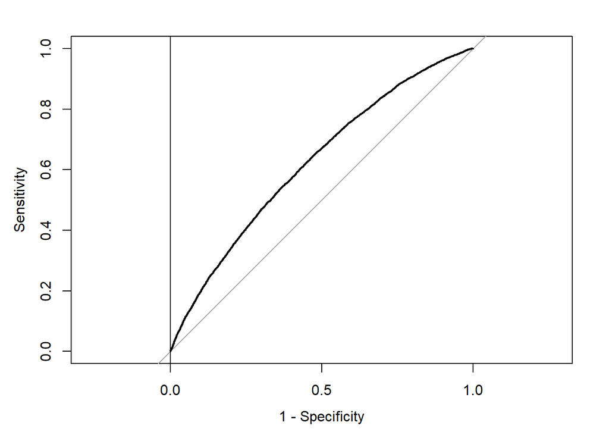

```r
plot.roc(roc1, legacy.axes = T)
abline(v=1)
```

#As per general rule if the curve gets closer to 45-degree diagonal of the ROC space it means that test is less accurate. #In this plot we can visually identify that curve is not in good position.

```r
auc(roc1)
```

```
## Area under the curve: 0.624
```

#AUC is good metrics to summarize the performance of each classifier. Here it is esentially equivalent to probability that a randomly chosen positive instance is ranked higher than a randomly chosen negative instance. AUC is approximately equal to 62% which is not quite good result. Therefore, there is a need to try different models and compare the results.

```r
# Split the data into training and test set
set.seed(123)
training.samples <- diabetic.unique7$early.readmit%>%
  createDataPartition(p = 0.5, list = FALSE)
train.data  <- diabetic.unique7[training.samples, ]
test.data <- diabetic.unique7[-training.samples, ]
# Build the model
model <- glm(early.readmit~discharge_disposition+admission.source+
                              admit.spec+prim.diag+race2+age3+time_in_hospital+HbA1c+
                              discharge_disposition:admit.spec+
                              discharge_disposition:prim.diag+
                              discharge_disposition:race2+
                              discharge_disposition:time_in_hospital+
                              admission.source:age3+
                              admit.spec:age3+
                              admit.spec:prim.diag+
                              admit.spec:time_in_hospital+
                              prim.diag:time_in_hospital+
                              HbA1c:prim.diag,
                     train.data, family = binomial, na.action = na.exclude)
# Make predictions and compute the R2, RMSE and MAE
predictions <- model %>% predict(test.data)

data.frame( R2 = R2(predictions, test.data$early.readmit, na.rm = TRUE),
            RMSE = RMSE(predictions, test.data$early.readmit,na.rm = TRUE),
            MAE = MAE(predictions, test.data$early.readmit, na.rm = TRUE))
```

```
##           R2     RMSE      MAE
## 1 0.01022156 2.574674 2.511719
```

#Checking prediction error rate based on RMSE.

```r
RMSE(predictions, test.data$early.readmit, na.rm = TRUE)/mean(test.data$early.readmit, na.rm = TRUE)
```

```
## [1] 28.35302
```

#Error is quite high. Apparently, the model is built on a fraction of the data set only. That’s why there is a still possiblity that some important information might not be included, which essentially leads to higher bias. The test error rate can be greatly variable, depending on which observations are included in the training set and which observations are included in the validation set. #That’s why subsequently I will try to make a new model by means of cross validation in order to compare the results.

```r
roc1 <- roc(early.readmit ~predictions, test.data, na.rm = TRUE)
```

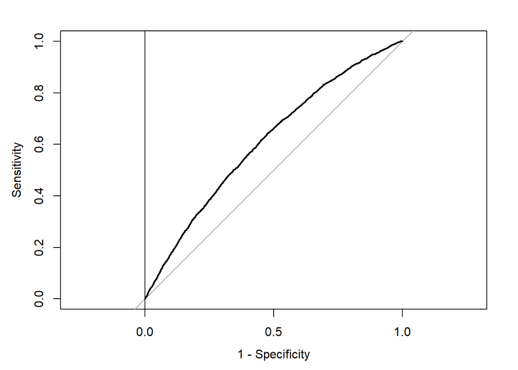

```r
plot.roc(roc1, legacy.axes = T)
abline(v=1)
```

```r
auc(roc1)
```

```
## Area under the curve: 0.611
```

#The reason why AUC is getting lower is related to the number of variables used in the prediction. AUC result is still not good.

#ggplot shows the change of early readmit per age group

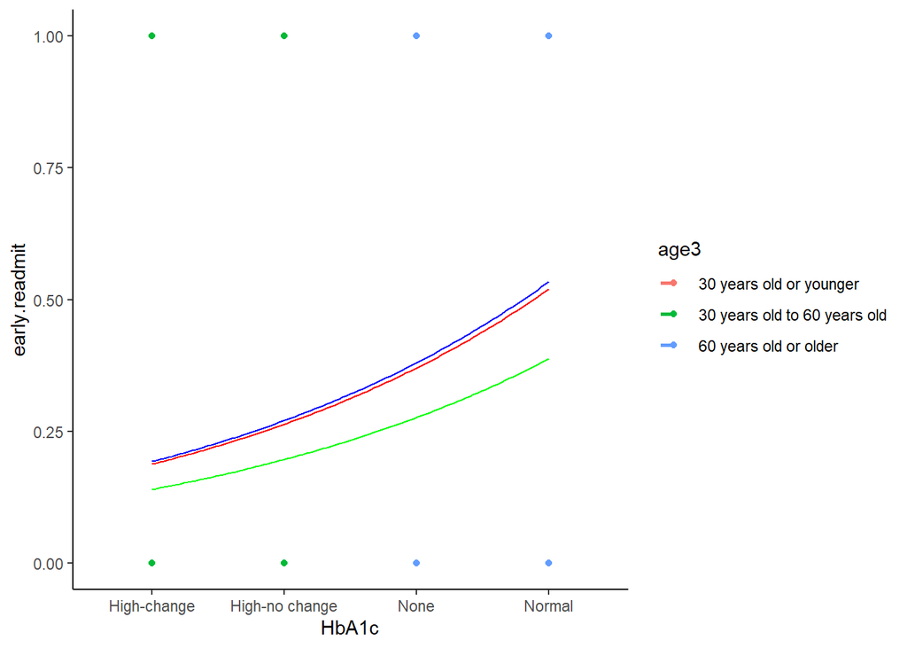

```r
fun.gen <- function(awd) exp(model$coef[1] + model$coef[2] * awd)
fun.acd <- function(awd) exp(model$coef[1] + model$coef[2] * awd + model$coef[3])
fun.voc <- function(awd) exp(model$coef[1] + model$coef[2] * awd + model$coef[4])

ggplot(train.data, aes(HbA1c, early.readmit, col = age3)) +
    geom_point() +
    stat_function(fun = fun.gen, col = "red") +
    stat_function(fun = fun.acd, col = "green") +
    stat_function(fun = fun.voc, col = "blue") +
    geom_smooth(method = "glm", se = F,
        method.args = list(family = "poisson"), linetype = "dashed")
```

#ggplot shows the change of early readmit per race

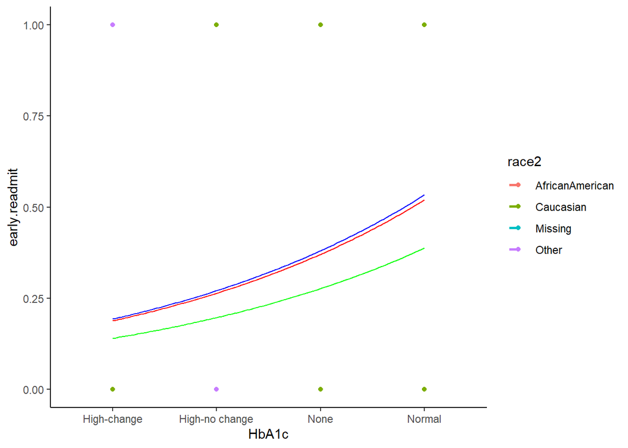

```r
fun.gen <- function(awd) exp(model$coef[1] + model$coef[2] * awd)
fun.acd <- function(awd) exp(model$coef[1] + model$coef[2] * awd + model$coef[3])
fun.voc <- function(awd) exp(model$coef[1] + model$coef[2] * awd + model$coef[4])

ggplot(train.data, aes(HbA1c, early.readmit, col = race2)) +
    geom_point() +
    stat_function(fun = fun.gen, col = "red") +
    stat_function(fun = fun.acd, col = "green") +
    stat_function(fun = fun.voc, col = "blue") +
    geom_smooth(method = "glm", se = F,
        method.args = list(family = "poisson"), linetype = "dashed")
```

#Cross validation (5 folds).

```r
# Define training control
final_ctrl <- trainControl(method = "cv", number = 5)
model_caret1 <- train(early.readmit~discharge_disposition+admission.source+
                              admit.spec+prim.diag+race2+age3+time_in_hospital+HbA1c+
                              discharge_disposition:admit.spec+
                              discharge_disposition:prim.diag+
                              discharge_disposition:race2+
                              discharge_disposition:time_in_hospital+
                              admission.source:age3+
                              admit.spec:age3+
                              admit.spec:prim.diag+
                              admit.spec:time_in_hospital+
                              prim.diag:time_in_hospital+
                              HbA1c:prim.diag,
                  data=diabetic.unique7,trControl = final_ctrl,
                     method = "glm", na.action = na.exclude)
print(model_caret1)
```

```
## Generalized Linear Model
##
## 69973 samples
##     8 predictor
##
## No pre-processing
## Resampling: Cross-Validated (5 fold)
## Summary of sample sizes: 55970, 55970, 55970, 55971, 55971
## Resampling results:
##
##   RMSE       Rsquared    MAE
##   0.2841153  0.01164235  0.1611943
```

#Cross validation (10 folds).

```r
# Define training control
final_ctrl1 <- trainControl(method = "cv", number = 10)
model_caret11 <- train(early.readmit~discharge_disposition+admission.source+
                              admit.spec+prim.diag+race2+age3+time_in_hospital+HbA1c+
                              discharge_disposition:admit.spec+
                              discharge_disposition:prim.diag+
                              discharge_disposition:race2+
                              discharge_disposition:time_in_hospital+
                              admission.source:age3+
                              admit.spec:age3+
                              admit.spec:prim.diag+
                              admit.spec:time_in_hospital+
                              prim.diag:time_in_hospital+
                              HbA1c:prim.diag,
                  data=diabetic.unique7,trControl = final_ctrl1,
                     method = "glm", na.action = na.exclude)
print(model_caret11)
```

```
## Generalized Linear Model
##
## 69973 samples
##     8 predictor
##
## No pre-processing
## Resampling: Cross-Validated (10 fold)
## Summary of sample sizes: 62967, 62967, 62967, 62967, 62967, 62966, ...
## Resampling results:
##
##   RMSE      Rsquared    MAE
##   0.284106  0.01173672  0.1611368
```

#According to above-given results our RMSE is getting smaller, R-squared is getting higher as the number of folds is going up which necessarily means that 10 cross-validations increase the goodness of fit. #By this method we use all data points reducing potential bias. #However, the process is repeated as many times as there are data points. #It clearly results in a higher execution time especially when we have big data.

#Examining model predictions for each fold after resampling (5cv-s).

```r
model_caret1$resample
```

```
##        RMSE    Rsquared       MAE Resample
## 1 0.2799207 0.014127677 0.1590816    Fold1
## 2 0.2862234 0.010610265 0.1622229    Fold2
## 3 0.2816702 0.009914887 0.1605172    Fold3
## 4 0.2851358 0.012251869 0.1614132    Fold4
## 5 0.2876264 0.011307062 0.1627363    Fold5
```

#Checking the standard deviation around the Rsquared value by examining the R-squared from each fold (5cv-s).

```r
sd(model_caret1$resample$Rsquared)
```

```
## [1] 0.001636315
```

#Examining model predictions for each fold after resampling (10 cv-s).

```r
model_caret11$resample
```

```
##         RMSE    Rsquared       MAE Resample
## 1  0.2801200 0.011603444 0.1586245   Fold01
## 2  0.2799318 0.009308857 0.1591856   Fold02
## 3  0.2869170 0.009095967 0.1624936   Fold03
## 4  0.2793627 0.009035847 0.1588915   Fold04
## 5  0.2853088 0.012436650 0.1609449   Fold05
## 6  0.2869969 0.014436864 0.1629223   Fold06
## 7  0.2860588 0.018454318 0.1622146   Fold07
## 8  0.2893948 0.009654059 0.1641836   Fold08
## 9  0.2824491 0.012423299 0.1602163   Fold09
## 10 0.2845202 0.010917876 0.1616911   Fold10
```

#Checking the standard deviation around the Rsquared value by examining the R-squared from each fold (10cv-s).

```r
sd(model_caret11$resample$Rsquared)
```

```
## [1] 0.002954596
```

#Moreover, the model checks the performance and tests it against one data point iteratively.  
#From this point, higher variation in the prediction error is inevitable in case some data points are outliers. #Therefore, k-fold cv method might be better option as the model is based on random splits.

```r
diabetic.unique7$prim.diag <- relevel(factor(diabetic.unique7$prim.diag), ref='Diabetes')


# Define training control
set.seed(123)
train.control1 <- trainControl(method = "repeatedcv",
                              number = 10, repeats = 3)

diabetic.unique7$medical_specialty <- as.numeric(diabetic.unique7$medical_specialty,  na.action = na.exclude)
diabetic.unique7$medical_specialty[is.na(diabetic.unique7$medical_specialty)] = mean(diabetic.unique7$medical_specialty,  na.action = na.exclude)

# Train the model
model <- train(early.readmit ~discharge_disposition+admission.source+
                              admit.spec+prim.diag+race2+age3+time_in_hospital+HbA1c+
                              discharge_disposition:admit.spec+
                              discharge_disposition:prim.diag+
                              discharge_disposition:race2+
                              discharge_disposition:time_in_hospital+
                              admission.source:age3+
                              admit.spec:age3+
                              admit.spec:prim.diag+
                              admit.spec:time_in_hospital+
                              prim.diag:time_in_hospital+
                              HbA1c:prim.diag, data = diabetic.unique7, method = "glm",
               trControl = train.control1, na.action = na.exclude)
# Summarize the results
print(model)
```

```
## Generalized Linear Model
##
## 69973 samples
##     8 predictor
##
## No pre-processing
## Resampling: Cross-Validated (10 fold, repeated 3 times)
## Summary of sample sizes: 62966, 62967, 62967, 62967, 62967, 62967, ...
## Resampling results:
##
##   RMSE       Rsquared    MAE
##   0.2840784  0.01172645  0.1611624
```